# 2.2陈曦2022217588

### 导入库文件

```python
import numpy as np
import os
import cv2
import plotly.express as px
import matplotlib.pyplot as plt
import seaborn as sns
import tensorflow as tf
from tensorflow.keras import layers, models
from tensorflow.keras.callbacks import ModelCheckpoint, EarlyStopping
from sklearn.metrics import accuracy_score, classification_report
```

### 问题描述

- 该数据集包含12,500张增强的血细胞图像（JPEG格式），并附有细胞类型标签（CSV格式）。
- 每种细胞类型大约有3,000张图像，这些图像根据细胞类型分为4个不同的文件夹。
- 细胞类型包括嗜酸性粒细胞（Eosinophil）、淋巴细胞（Lymphocyte）、单核细胞（Monocyte）和中性粒细胞（Neutrophil）。
- 目标：模型需要从这个数据中学习，识别目标细胞的类型。

### 导入数据

- 文件夹 dataset-master 包含 410 张带有亚型标签和边界框的血细胞图像（JPEG + XML），
- 文件夹 dataset2-master 包含 12,500 张增强的图像以及 4 种额外的亚型标签（JPEG + CSV）。
- dataset-master 文件夹中四种类型细胞分别有88、33、21 和 207张图像
- dataset2-master 文件夹中四种类型细胞约有 3,000 张增强的图像。

```python
train_dir = '../blood/archive/dataset2-master/dataset2-master/images/TRAIN'
test_dir = '../blood/archive/dataset2-master/dataset2-master/images/TEST'
```

```python
print('Training samples:')
num_samples = 0
for cell in os.listdir(train_dir):
    num_cells = len(os.listdir(os.path.join(train_dir, cell)))
    num_samples += num_cells
    print('Cell: {:15s}  num samples: {:d}'.format(cell, num_cells))
print('Total training samples: {:d}\n'.format(num_samples))

print('Test samples:')

num_samples = 0
for cell in os.listdir(test_dir):
    num_cells = len(os.listdir(os.path.join(test_dir, cell)))
    num_samples += num_cells
    print('Cell: {:15s}  num samples: {:d}'.format(cell, num_cells))
print('Total test samples: {:d}'.format(num_samples))
```

```
Training samples:
Cell: EOSINOPHIL       num samples: 2497
Cell: LYMPHOCYTE       num samples: 2483
Cell: MONOCYTE         num samples: 2478
Cell: NEUTROPHIL       num samples: 2499
Total training samples: 9957

Test samples:
Cell: EOSINOPHIL       num samples: 623
Cell: LYMPHOCYTE       num samples: 620
Cell: MONOCYTE         num samples: 620
Cell: NEUTROPHIL       num samples: 624
Total test samples: 2487
```

### 细胞类型展示

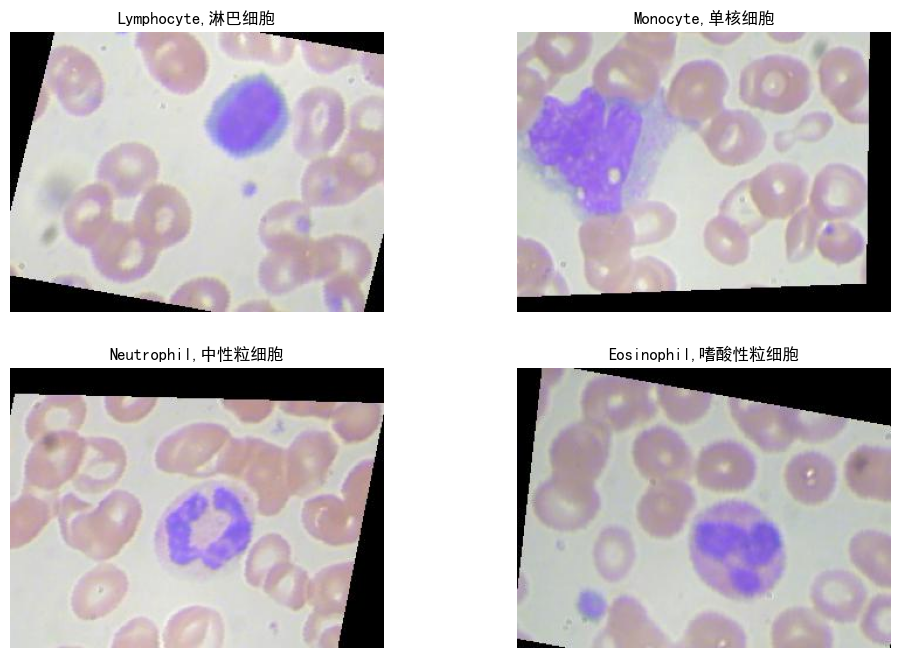

```python
# Plot Image
def plotImage(image_path):
    image = cv2.imread(image_path)  # BGR
    image = image[:, :, [2, 1, 0]]  # Reorder to RGB for Matplotlib display
    plt.imshow(image)
    return
plt.rcParams['font.sans-serif']=['SimHei']
plt.rcParams['axes.unicode_minus'] =False
plt.figure(figsize=(12,8))
plt.subplot(221)
plt.title('Lymphocyte,淋巴细胞'); plt.axis('off'); plotImage(os.path.join(train_dir, 'LYMPHOCYTE/_0_204.jpeg'))
plt.subplot(222)
plt.title('Monocyte,单核细胞'); plt.axis('off'); plotImage(os.path.join(train_dir, 'MONOCYTE/_0_9309.jpeg'))
plt.subplot(223)
plt.title('Neutrophil,中性粒细胞'); plt.axis('off'); plotImage(os.path.join(train_dir, 'NEUTROPHIL/_0_9742.jpeg'))
plt.subplot(224)
plt.title('Eosinophil,嗜酸性粒细胞'); plt.axis('off'); plotImage(os.path.join(train_dir, 'EOSINOPHIL/_5_907.jpeg'))
```

### 构建图像数据生成器 (ImageDataGenerator)，用于在训练神经网络时从目录中读取图像数据，并进行预处理。

```python
# generator
#归一化
train_gen = tf.keras.preprocessing.image.ImageDataGenerator(
    rescale=1.0/255,
    validation_split=0.2
)

test_gen = tf.keras.preprocessing.image.ImageDataGenerator(
    rescale=1.0/255,
)
```

```python
# 载入

train_images = train_gen.flow_from_directory(
    directory=train_dir,
    target_size=(244,244),
    class_mode='categorical',
    batch_size=16,
    shuffle=True,
    subset='training'
)

val_images = train_gen.flow_from_directory(
    directory=train_dir,
    target_size=(244,244),
    class_mode='categorical',
    batch_size=16,
    shuffle=False,
    subset='validation'
)

test_images = test_gen.flow_from_directory(
    directory=test_dir,
    target_size=(244,244),
    class_mode='categorical',
    batch_size=16,
    shuffle=False,
)
```

```
Found 7968 images belonging to 4 classes.
Found 1989 images belonging to 4 classes.
Found 2487 images belonging to 4 classes.
```

### CNN构建

- 本次数据集为血细胞图像，CNN 是处理图像数据的主要模型类型，因为它能够有效地捕捉图像的空间和局部特征，故选择了CNN模型

```python
model = models.Sequential()

# 卷积层
model.add(layers.Conv2D(64, (5, 5), strides=2, activation='relu', input_shape=(244,244, 3)))
model.add(layers.MaxPooling2D((2, 2), strides=2))
model.add(layers.Conv2D(256, (3, 3),strides=2, activation='relu'))
model.add(layers.MaxPooling2D((3, 3), strides=2))
model.add(layers.Conv2D(128, (3, 3),strides=2, activation='relu'))
model.add(layers.MaxPooling2D((2, 2), strides=1))


# 扁平化
model.add(layers.Flatten())

# 全连接
model.add(layers.Dense(256, activation='relu'))
model.add(layers.Dropout(0.5))  #减少过拟合风险
model.add(layers.Dense(4, activation='softmax'))  # 多分类问题

# 编译
optimizer = tf.keras.optimizers.Adam(learning_rate=0.0002)
model.compile(optimizer= optimizer, loss='categorical_crossentropy', metrics=['accuracy'])

# 摘要
model.summary()
```

```
Model: "sequential_3"
```

```
┏━━━━━━━━━━━━━━━━━━━━━━━━━━━━━━━━━┳━━━━━━━━━━━━━━━━━━━━━━━━┳━━━━━━━━━━━━━━━┓
┃ Layer (type)                    ┃ Output Shape           ┃       Param # ┃
┡━━━━━━━━━━━━━━━━━━━━━━━━━━━━━━━━━╇━━━━━━━━━━━━━━━━━━━━━━━━╇━━━━━━━━━━━━━━━┩
│ conv2d_9 (Conv2D)               │ (None, 120, 120, 64)   │         4,864 │
├─────────────────────────────────┼────────────────────────┼───────────────┤
│ max_pooling2d_9 (MaxPooling2D)  │ (None, 60, 60, 64)     │             0 │
├─────────────────────────────────┼────────────────────────┼───────────────┤
│ conv2d_10 (Conv2D)              │ (None, 29, 29, 256)    │       147,712 │
├─────────────────────────────────┼────────────────────────┼───────────────┤
│ max_pooling2d_10 (MaxPooling2D) │ (None, 14, 14, 256)    │             0 │
├─────────────────────────────────┼────────────────────────┼───────────────┤
│ conv2d_11 (Conv2D)              │ (None, 6, 6, 128)      │       295,040 │
├─────────────────────────────────┼────────────────────────┼───────────────┤
│ max_pooling2d_11 (MaxPooling2D) │ (None, 5, 5, 128)      │             0 │
├─────────────────────────────────┼────────────────────────┼───────────────┤
│ flatten_3 (Flatten)             │ (None, 3200)           │             0 │
├─────────────────────────────────┼────────────────────────┼───────────────┤
│ dense_6 (Dense)                 │ (None, 256)            │       819,456 │
├─────────────────────────────────┼────────────────────────┼───────────────┤
│ dropout_3 (Dropout)             │ (None, 256)            │             0 │
├─────────────────────────────────┼────────────────────────┼───────────────┤
│ dense_7 (Dense)                 │ (None, 4)              │         1,028 │
└─────────────────────────────────┴────────────────────────┴───────────────┘
```

```
 Total params: 1,268,100 (4.84 MB)
```

```
 Trainable params: 1,268,100 (4.84 MB)
```

```
 Non-trainable params: 0 (0.00 B)
```

### 模型训练

```python
# Save best model
weight_path = '/blood/.weights.h5'

early_stopping = EarlyStopping(monitor='val_accuracy', patience=5)

model_checkpoint = ModelCheckpoint(
    filepath = weight_path,
    save_best_only = True,
    save_weights_only = True,
    mode = 'max',
    monitor = 'val_accuracy'
)

tf.random.set_seed(42)
epoch = 20

history = model.fit(train_images, epochs=epoch, validation_data=val_images, callbacks=[model_checkpoint, early_stopping])
```

```
498/498 ━━━━━━━━━━━━━━━━━━━━ 41s 80ms/step - accuracy: 0.2412 - loss: 1.3914 - val_accuracy: 0.2494 - val_loss: 1.3859
498/498 ━━━━━━━━━━━━━━━━━━━━ 40s 80ms/step - accuracy: 0.2751 - loss: 1.3754 - val_accuracy: 0.4605 - val_loss: 1.1600
498/498 ━━━━━━━━━━━━━━━━━━━━ 40s 80ms/step - accuracy: 0.4925 - loss: 1.1072 - val_accuracy: 0.6144 - val_loss: 0.8574
498/498 ━━━━━━━━━━━━━━━━━━━━ 40s 81ms/step - accuracy: 0.6272 - loss: 0.8426 - val_accuracy: 0.7024 - val_loss: 0.7104
498/498 ━━━━━━━━━━━━━━━━━━━━ 41s 82ms/step - accuracy: 0.6733 - loss: 0.7325 - val_accuracy: 0.7074 - val_loss: 0.6897
498/498 ━━━━━━━━━━━━━━━━━━━━ 41s 82ms/step - accuracy: 0.7307 - loss: 0.6179 - val_accuracy: 0.7557 - val_loss: 0.5698
498/498 ━━━━━━━━━━━━━━━━━━━━ 41s 83ms/step - accuracy: 0.7582 - loss: 0.5312 - val_accuracy: 0.8105 - val_loss: 0.4578
498/498 ━━━━━━━━━━━━━━━━━━━━ 41s 83ms/step - accuracy: 0.7916 - loss: 0.4756 - val_accuracy: 0.8064 - val_loss: 0.4236
498/498 ━━━━━━━━━━━━━━━━━━━━ 41s 82ms/step - accuracy: 0.8259 - loss: 0.4059 - val_accuracy: 0.8547 - val_loss: 0.3458
498/498 ━━━━━━━━━━━━━━━━━━━━ 42s 83ms/step - accuracy: 0.8508 - loss: 0.3449 - val_accuracy: 0.8708 - val_loss: 0.3108
498/498 ━━━━━━━━━━━━━━━━━━━━ 41s 83ms/step - accuracy: 0.8729 - loss: 0.3004 - val_accuracy: 0.8834 - val_loss: 0.2872
498/498 ━━━━━━━━━━━━━━━━━━━━ 37s 75ms/step - accuracy: 0.8795 - loss: 0.2880 - val_accuracy: 0.8582 - val_loss: 0.2990
498/498 ━━━━━━━━━━━━━━━━━━━━ 37s 73ms/step - accuracy: 0.9010 - loss: 0.2405 - val_accuracy: 0.9060 - val_loss: 0.2249
498/498 ━━━━━━━━━━━━━━━━━━━━ 38s 75ms/step - accuracy: 0.9037 - loss: 0.2305 - val_accuracy: 0.8612 - val_loss: 0.3061
498/498 ━━━━━━━━━━━━━━━━━━━━ 38s 75ms/step - accuracy: 0.9180 - loss: 0.1941 - val_accuracy: 0.8899 - val_loss: 0.2393
498/498 ━━━━━━━━━━━━━━━━━━━━ 37s 75ms/step - accuracy: 0.9284 - loss: 0.1906 - val_accuracy: 0.9065 - val_loss: 0.2259
498/498 ━━━━━━━━━━━━━━━━━━━━ 38s 75ms/step - accuracy: 0.9311 - loss: 0.1664 - val_accuracy: 0.9065 - val_loss: 0.2188
498/498 ━━━━━━━━━━━━━━━━━━━━ 37s 75ms/step - accuracy: 0.9361 - loss: 0.1566 - val_accuracy: 0.9160 - val_loss: 0.1975
498/498 ━━━━━━━━━━━━━━━━━━━━ 37s 73ms/step - accuracy: 0.9542 - loss: 0.1286 - val_accuracy: 0.9271 - val_loss: 0.1733
498/498 ━━━━━━━━━━━━━━━━━━━━ 38s 76ms/step - accuracy: 0.9492 - loss: 0.1290 - val_accuracy: 0.9246 - val_loss: 0.1669
```

```python
fig = px.line(
    history.history,
    y=['loss', 'val_loss'],
    labels={'index': "Epoch", 'value': "Loss"},
    title="训练误差以及验证误差-2022217588-陈曦"
)

fig.show()
fig1 = px.line(
    history.history,
    y=['accuracy', 'val_accuracy'],
    labels={'index': "Epoch", 'value': "Accuracy"},
    title="训练准确率以及验证准确率-2022217588-陈曦"
)

fig1.show()
```

[output not shown]

```python
CLASS_NAMES = list(train_images.class_indices.keys())
CLASS_NAMES
```

```
['EOSINOPHIL', 'LYMPHOCYTE', 'MONOCYTE', 'NEUTROPHIL']
```

## 测试结果

##### 使用的性能指标：

- 混淆矩阵 (confusion matrix)
- 准确率 (accuracy)
- 分类报告，包含精确率、召回率、F1 分数和支持数

```
  4/156 ━━━━━━━━━━━━━━━━━━━━ 3s 21ms/step
```

```
156/156 ━━━━━━━━━━━━━━━━━━━━ 4s 23ms/step
Test Accuracy: 82.027%
```

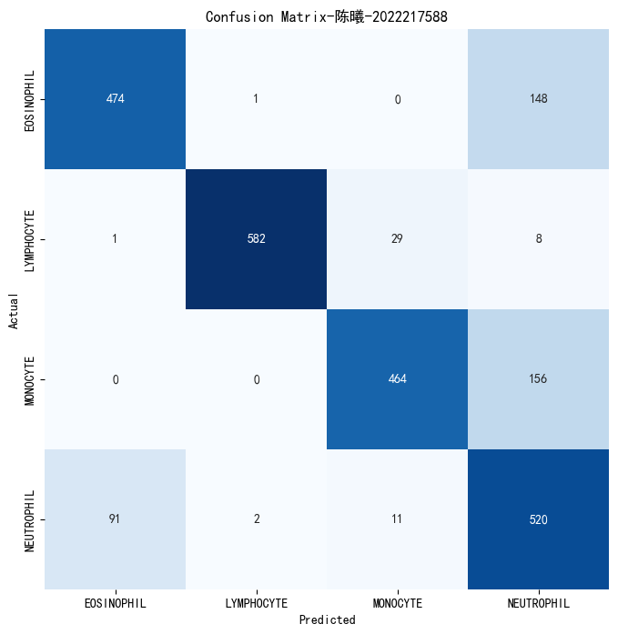

```
Classification Report-陈曦-2022217588:
----------------------
               precision    recall  f1-score   support

  EOSINOPHIL       0.84      0.76      0.80       623
  LYMPHOCYTE       0.99      0.94      0.97       620
    MONOCYTE       0.92      0.75      0.83       620
  NEUTROPHIL       0.62      0.83      0.71       624

    accuracy                           0.82      2487
   macro avg       0.84      0.82      0.83      2487
weighted avg       0.84      0.82      0.83      2487
```

```python
predictions = np.argmax(model.predict(test_images), axis=1)

acc = accuracy_score(test_images.labels, predictions)
cm = tf.math.confusion_matrix(test_images.labels, predictions)
clr = classification_report(test_images.labels, predictions, target_names=CLASS_NAMES)

print("Test Accuracy: {:.3f}%".format(acc * 100))

plt.figure(figsize=(8, 8))
sns.heatmap(cm, annot=True, fmt='g', vmin=0, cmap='Blues', cbar=False)
plt.xticks(ticks= np.arange(4) + 0.5, labels=CLASS_NAMES)
plt.yticks(ticks= np.arange(4) + 0.5, labels=CLASS_NAMES)
plt.xlabel("Predicted")
plt.ylabel("Actual")
plt.title("Confusion Matrix-陈曦-2022217588")
plt.show()

print("Classification Report-陈曦-2022217588:\n----------------------\n", clr)
```